# Capstone Swiftkey Exploratory Analysis

## Introduction

The goal of the project is to be able to predict the words that follow from it’s preceding text. The data comes from three sources: blogs, twitter, and the news.

Anyways, the english data is first loaded.

```r
options(warn=-1) #Suppress warnings

#Packages
library(ggplot2)
library(tm)
library(wordcloud)
library(RWeka)

#Data
dir = 'input/en_US/'
blogs = readLines(paste0(dir,"en_US.blogs.txt"))
twitter = readLines(paste0(dir,"en_US.twitter.txt"))
con = file(paste0(dir,"en_US.news.txt"), open="rb")
news = readLines(con, encoding="UTF-8")
close(con)
```

## Analysis of datasets

```r
data.frame(dataset=c("blogs", "news", "twitter"), num_lines=(c(length(blogs), length(news),length(twitter))), max_length=c(nchar(blogs[which.max(nchar(blogs))]), nchar(news[which.max(nchar(news))]), nchar(twitter[which.max(nchar(twitter))])))
```

```
##   dataset num_lines max_length
## 1   blogs    899288      40835
## 2    news   1010242      11384
## 3 twitter   2360148        213
```

As can be seen in this data frame, twitter seems to have the largest number of elements compared to the other datasets. Blogs has the longest length followed by news. The longest tweet is a bit under the 213 which is odd considering the max length of 140. The data will be sampled for training data.

```r
#Takes sampling of each data
train_blogs = sample(blogs, 50000)
train_news = sample(news, 50000)
train_twitter = sample(twitter, 50000)
```

## Creating the training data and ngrams and its examination

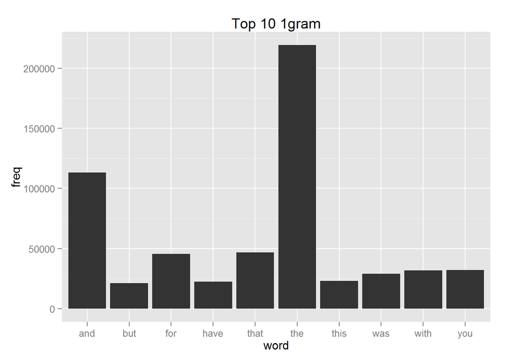

```r
#Combine the datasets and begin to create the corpus of words
combined_raw = c(train_blogs,  train_news, train_twitter)

corpus = Corpus(VectorSource(combined_raw))
corpus = tm_map(corpus, removeNumbers) # remove numbers
corpus = tm_map(corpus, stripWhitespace) # remove whitespaces
corpus = tm_map(corpus, tolower) #lowercase all contents
corpus = tm_map(corpus, removePunctuation) # remove punctuation
corpus = tm_map(corpus, removeWords, c("fuck", "bitch", "ass", "cunt", "pussy", "asshole", "douche")) #remove some swears
corpus = tm_map(corpus, PlainTextDocument) #convert to plaintextdocument


#Convert to DocumentTermMatrix and remove sparse terms
ngram1 = DocumentTermMatrix(corpus)

ngram1 = removeSparseTerms(ngram1, 0.995) #keep words in that appear in 99.5%
ngram1 = as.data.frame(as.matrix(ngram1))

#Word cloud of the most frequent words
word_freqs = sort(colSums(ngram1), decreasing=TRUE)
dm = data.frame(word=names(word_freqs), freq=word_freqs)
ordered= dm[order(dm$freq, decreasing=TRUE),]
ordered = ordered[1:10,]
ggplot(ordered, aes(x=word, y=freq)) + geom_histogram(stat="identity") + labs(title="Top 10 1gram")
```

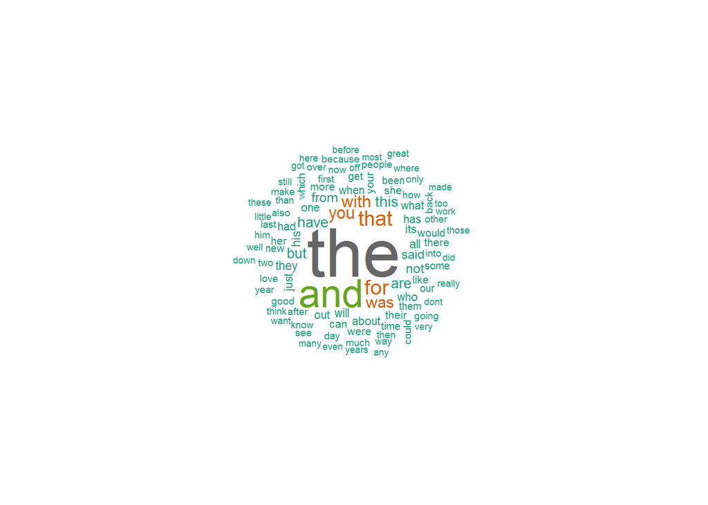

```r
wordcloud(dm$word, dm$freq, random.order=FALSE, colors=brewer.pal(8, "Dark2"), max.words=100)
```

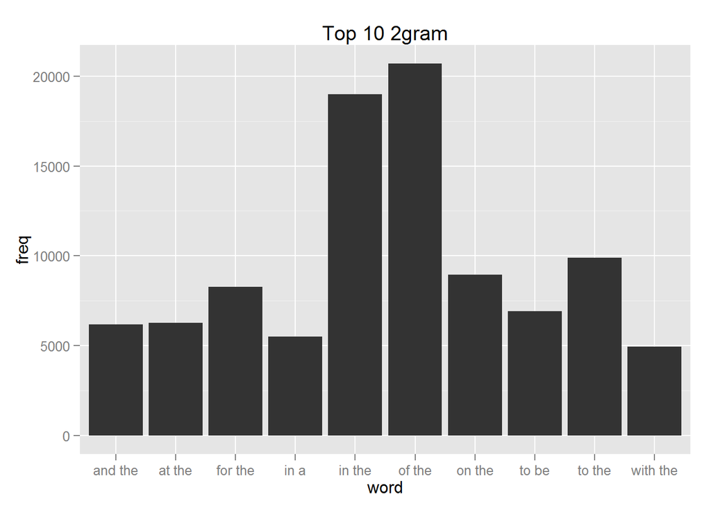

```r
#Create n-grams of 2
TwogramTokenizer = function(x) NGramTokenizer(x, Weka_control(min = 2, max = 2))
ngram2 = TermDocumentMatrix(corpus, control = list(tokenize = TwogramTokenizer))
ngram2 = removeSparseTerms(ngram2, 0.995)

#Word cloud of frequent 2grams
m = as.matrix(ngram2)
word_freqs = sort(rowSums(m), decreasing=TRUE)
dm = data.frame(word=names(word_freqs), freq=word_freqs)
ordered= dm[order(dm$freq, decreasing=TRUE),]
ordered = ordered[1:10,]
ggplot(ordered, aes(x=word, y=freq)) + geom_histogram(stat="identity") + labs(title="Top 10 2gram")
```

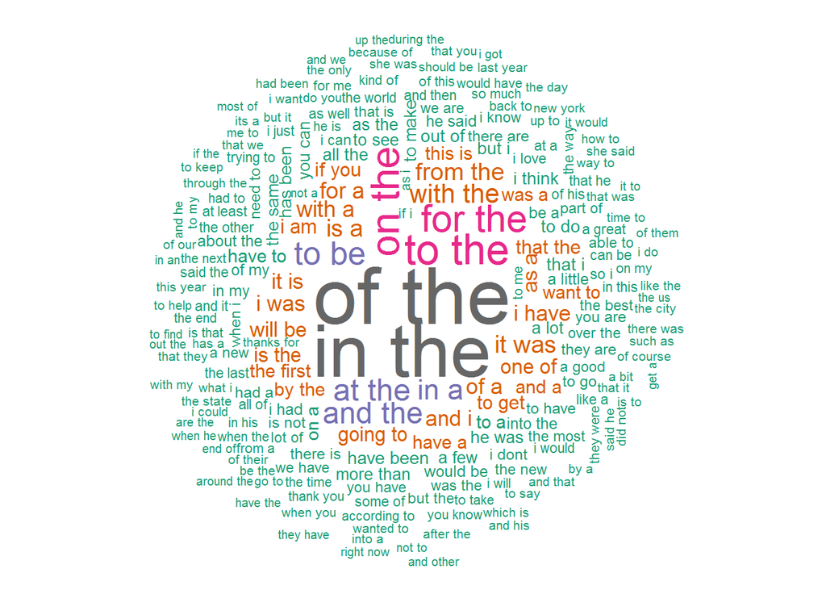

```r
wordcloud(dm$word, dm$freq, random.order=FALSE, colors=brewer.pal(8, "Dark2"))
```

Like the previous case with the most common words, the 2grams appears to be conneting statements. In addition to the connceting statements, there are those such as to do and other verb phrases. There are also descriptive statements such as “the us.”

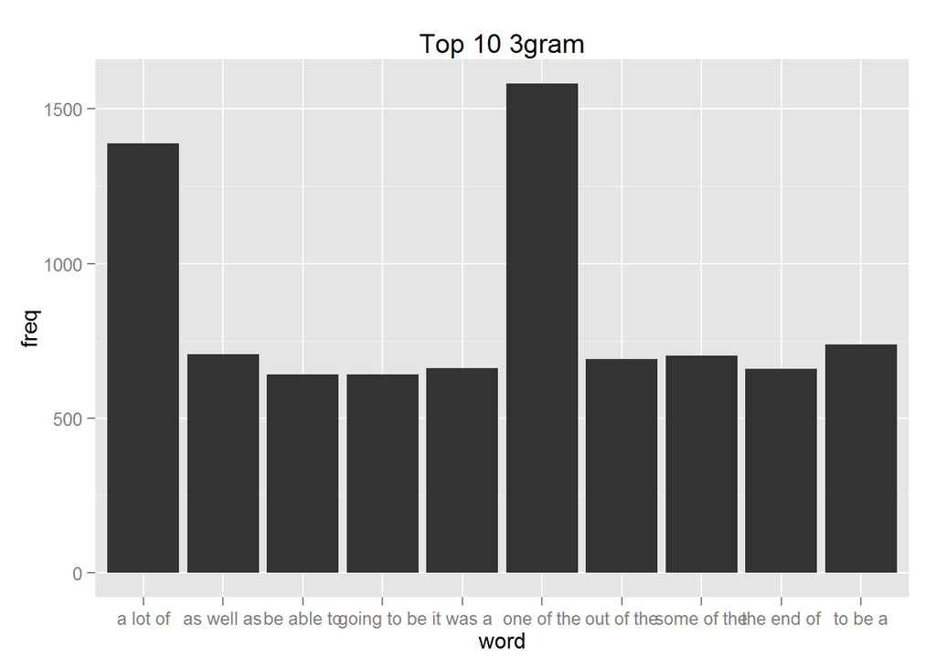

```r
#Create n-gram of 3
TrigramTokenizer = function(x) NGramTokenizer(x, Weka_control(min = 3, max = 3))
ngram3 = TermDocumentMatrix(corpus, control = list(tokenize = TrigramTokenizer))
ngram3 = removeSparseTerms(ngram3, 0.999)

#Word cloud of frequent 3gram
m = as.matrix(ngram3)
word_freqs = sort(rowSums(m), decreasing=TRUE)
dm = data.frame(word=names(word_freqs), freq=word_freqs)
ordered= dm[order(dm$freq, decreasing=TRUE),]
ordered = ordered[1:10,]
ggplot(ordered, aes(x=word, y=freq)) + geom_histogram(stat="identity") + labs(title="Top 10 3gram")
```

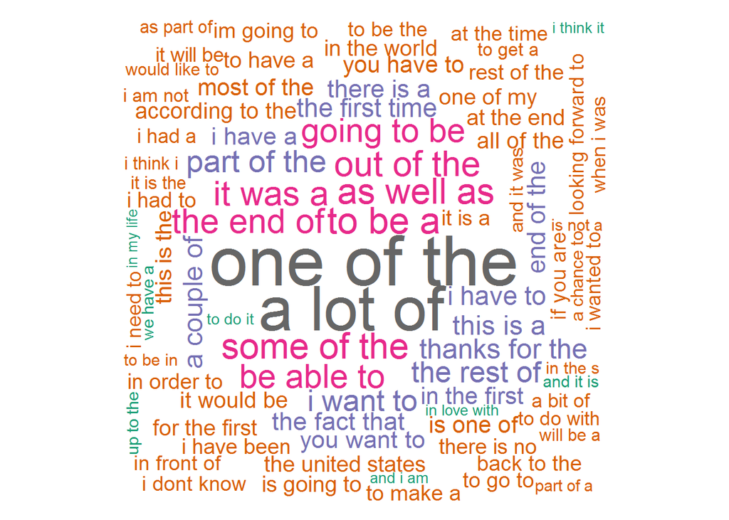

```r
wordcloud(dm$word, dm$freq, random.order=FALSE, colors=brewer.pal(8, "Dark2"))
```

Similar to the others, these 3grams are utilize a lot fo connecting phrases. Some fo the three grams are common in everyday speech such as connecting phrases, what one wants to do or say, or common locales like the united states.

## Plans for building the prediction algorithm

I plan to build my model primarily utilizing the ngram sequences gathered from the data. The words following the start of a sentence should be able to be predicted based on probablity from ngram sequences. A nice feature to add would be have a prediction algorithm based on the first letter input as well as any following characters until completetion. I will need to look into how to cold start unseen training words as well as how to store the input data.